# Guía básica de R

3.Gráficas básicas y combinadas + Paquete lubridate + Introducción a los bucles for

Óscar García Hernández

27 de octubre de 2018

# Intro

A la hora de analizar cualquier tipo de datos, es muy interesante visualizarlos mediante gráficas. Esto nos permite asimilar de manera visual el comportamiento de una variable. Por ello, este capítulo va a ir enfocado a graficar en R, y hacer una pequeña introducción a todas las posibilidades que este software nos ofrece para llevar a cabo este comentido.  
Como ya remarqué en el capitulo anterior, para seguir esta guía es importante estar dentro del directorio de trabajo de github y ejecutar una serie de paquetes para poder trabajar con la lista *Datos*,

```r
library(rlist)
library(here)

Datos<- list.load(here::here("data/Datos_anemometros.rdata"))
```

# Plots

Para ir familiarizandonos con la jerga de R. Una gráfica es un “Plot”. Antes de comenzar a plotear cosas vamos a extraer los datos del termometro + higrómetro 7.

```r
term_hig7 <- Datos$term_hig7
```

Comentar rápidamente que es interesante acostumbrarnos a nombrar a las variables de manera clave y clara. Es decir, ya leyendo el nombre de una variable debo saber que contiene.Por eso no os de miedo poner nombres largos a las variables, es aconsejable que no sea un nombre kilométrico pero si que me de la información necesaria para saber que contiene.  
En lo referido a la nomenclatura de las variables es interesante remarcar que la única norma es que el nombre que le vallamos a poner no interfiera con una función de R, es muy problable que se produzcan conflictos. Es decir, **no nombraremos a una variable: vector, porque R tienen un comando que se llama vector, por ejemplo, podemos usar el nombre vector_1**  
Como ya vimos en el anterior capítulo usamos head para analizar la tabla term_hig7.

```r
head(term_hig7)
```

```
##   s/since_1/1/1970    date_string_hour temp (ÂºC) Humedad (%)
## 1       1540304407 23/10/2018 16:20:07       17.9          60
## 2       1540303984 23/10/2018 16:13:04       17.8          57
## 3       1540303563 23/10/2018 16:06:03       18.4          56
## 4       1540303141 23/10/2018 15:59:01       18.2          59
## 5       1540302719 23/10/2018 15:51:59       18.7          57
## 6       1540302295 23/10/2018 15:44:55       19.1          55
```

Vemos que la tabla contiene información de fecha en dos formatos, temperatura y humedad relativa.

```r
class(term_hig7$`temp (ÂºC)`)
```

```
## [1] "factor"
```

Como vimos en el capítulo anterior. Nos volvemos a encontrar con el problema de datos tipo “factor”. Por ello, lo resolvemos de la manera que ya vimos.

```r
#columna de temperatura
term_hig7$`temp (ÂºC)` <- as.numeric(as.character(term_hig7$`temp (ÂºC)`))

#Columna de humedad
term_hig7$`Humedad (%)` <- as.numeric(as.character(term_hig7$`Humedad (%)`))
```

Una vez hemos resuelto este problema. Podemos empezar a graficar los datos. Normalmente el se usa el comando plot especificando cual es el eje x y cual es el eje y.

```r
plot(x,y)
```

Pero como nuestros datos representan una serie temporal podemos plotearlos únicamente usando el eje y, ya que el eje x representa el tiempo.

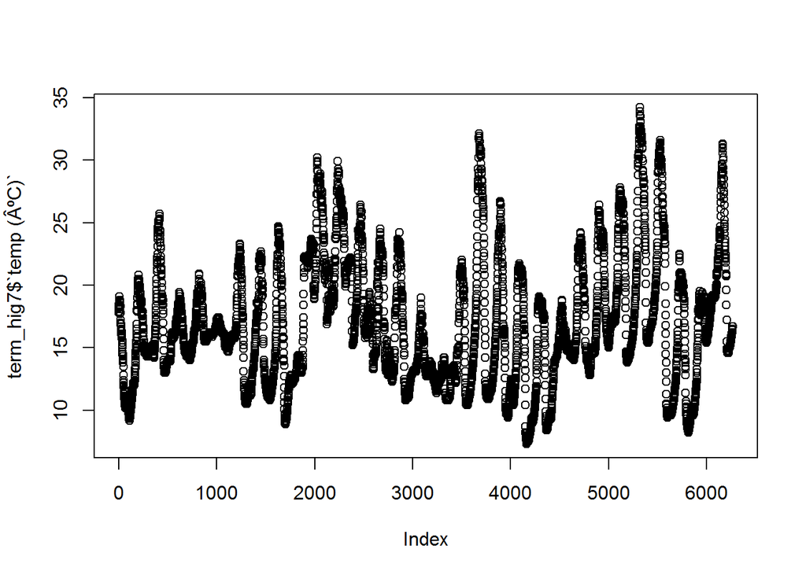

```r
plot(term_hig7$`temp (ÂºC)`)
```

Observamos que en el eje y tenemos la temperatura y el eje x, contiene únicamente un vector de posiciones.

# Modificar plots

## Modificar labels, ylab y xlab

Podemos modificar la etiqueta del eje x y del eje y. Usando dentro del plot: *ylab* y *xlab*

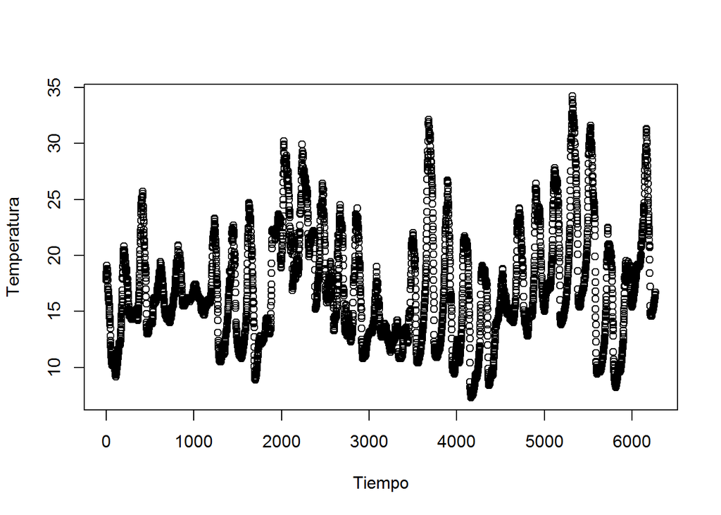

```r
plot(term_hig7$`temp (ÂºC)`, ylab = "Temperatura", xlab = "Tiempo")
```

## Modificar los ejes, comando axis()

Si queremos modificar lo que se representa en el eje x, podemos usar la siguiente opción.

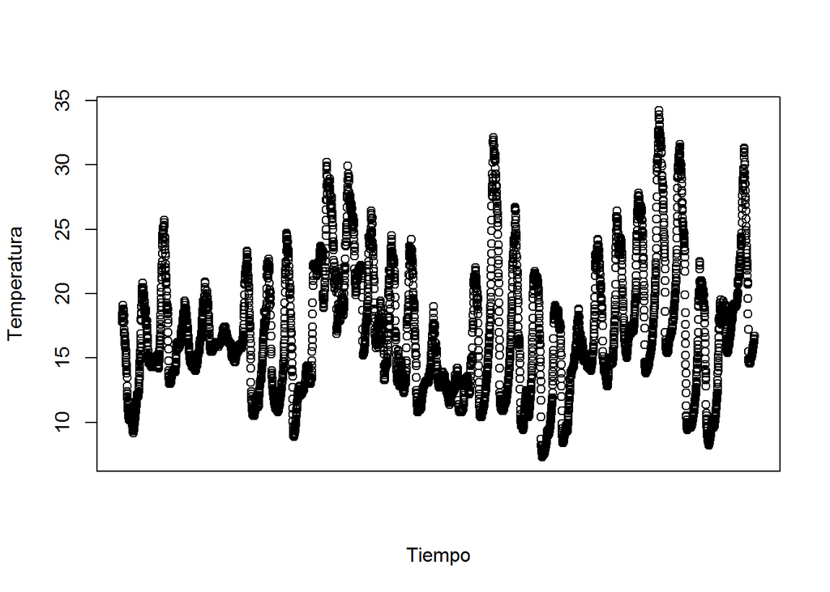

```r
#Ponemos xaxt="n", dentro del plot y  vemos como desaparece la infor del eje x.

plot(term_hig7$`temp (ÂºC)`,
     ylab = "Temperatura",
     xlab = "Tiempo",
     xaxt="n")
```

De esta manera desaparece la información del eje x. Y ahora podemos modificarla usando el comando **axis()**. Vamos a representar 5 fechas en el eje x.  
Para plotear 5 fechas equidistantes creamos un vector usando *seq(inicio,final,length.out= 5)*. Donde el final será el último término de vector que hemos ploteado.

```r
#Indicamos la posicion donde queremos plotear las "etiquetas".
posicion_eje <- seq(1,length(term_hig7$date_string_hour),length.out = 5)
```

Si ejecutamos **posicion_eje**. Podemos ver las posiciones donde estarán las etiquetas.  
Ahora tenemos que especificar que aparece en las etiquetas del eje. Por lo tanto plotearemos las etiquetas contenidas en la columna de fecha en formato palabra. **term_hig7$date_string_hour** para esas posiciones.

```r
etiquetas <- term_hig7$date_string_hour[posicion_eje]
```

Una vez hemos decidido cuantas posiciones vamos a poner en el eje x y que vamos a poner en cada posición ejecutamos el comando **axis()**.

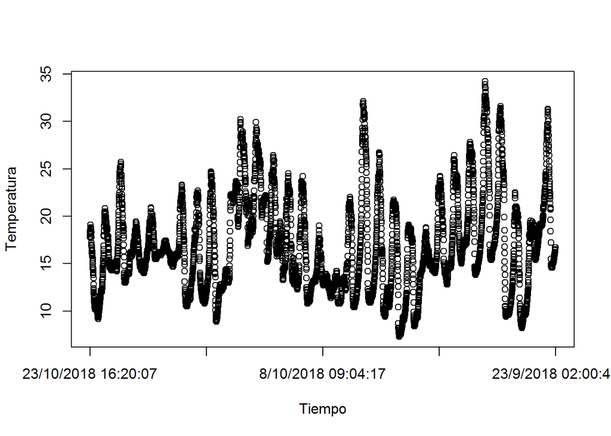

```r
#Ponemos axis(1, ...). Porque el 1 hace referencia al eje x.
#Si fueramos a modificar el eje y pondríamos axis(2, ...)

axis(1,at = posicion_eje,labels = etiquetas)
```

Para ver las gráficas con mejor detalle podemos pulsar “Zoom” en la ventana de plots y se abrirá una ventan independiente de mayor tamaño, que nos permitirá ver mejor la gráfica.

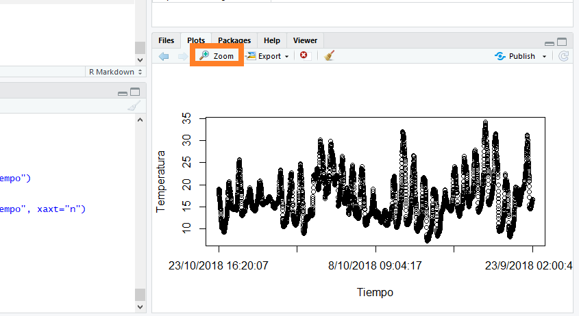

> ¿Ven algo raro en la gráfica?

Yo sí, los datos están cronológicamente mal ordenados. Lo normal es que el tiempo aumente con el eje x, no al revés como pasa en esta gráfica.  
El comando **rev()** sirve para revertir series de datos.

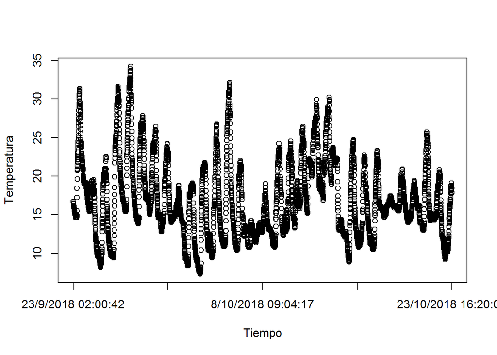

```r
# usamos rev en el plot
plot(rev(term_hig7$`temp (ÂºC)`),
     ylab = "Temperatura",
     xlab = "Tiempo",
     xaxt="n")

posicion_eje <- seq(1,length(term_hig7$date_string_hour),length.out = 5)

#usamos rev para revertir tambien las etiquetas del eje.
etiquetas <- rev(term_hig7$date_string_hour[posicion_eje])
axis(1,at = posicion_eje,labels = etiquetas)
```

## Modificar límites

Muchas veces es necesario modicar el tamaño de un plot. Para ello podemos: Cambiar el tamaño de los datos ploteados o directamente usar **xlim e ylim**

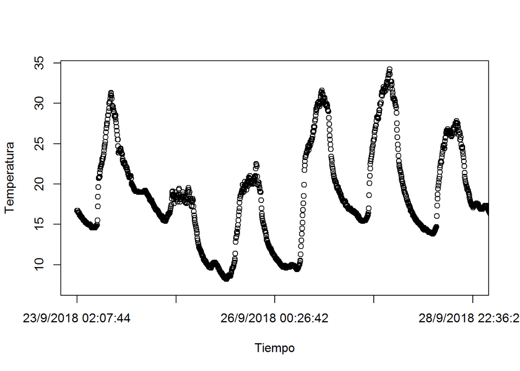

```r
#xlim en forma de vector para decir cual es él limite por la izquierda y derecha
plot(rev(term_hig7$`temp (ÂºC)`),
     ylab = "Temperatura",
     xlab = "Tiempo",
     xaxt="n",
     xlim = c(0,1200))


#hay que usar la lógica para poder ajustar las etiquetas de los ejes.

posicion_eje <- seq(1,1200,length.out = 5)

etiquetas <- term_hig7$date_string_hour[length(term_hig7$`temp (ÂºC)`) - posicion_eje]
axis(1,at = posicion_eje,labels = etiquetas)
```

La otra manera, es acotar los datos que vamos a plotear. Dentro de la tabla los datos correspondientes al 22/10/2018 están comprendidos entre la fila 141 y la fila 345.Creamos una nueva tabla que únicamente tenga estas filas.

```r
Datos_dia_22_oct <- term_hig7[141:345,]
```

Ploteamos estos datos, teniendo en cuenta que hay que dar la vuelta a la tabla.

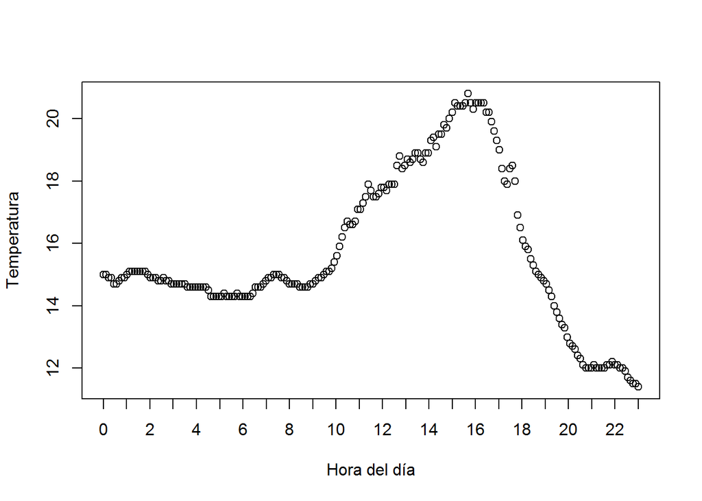

```r
plot(rev(Datos_dia_22_oct$`temp (ÂºC)`),
     xlab = "Hora del día",
     ylab = "Temperatura",
     xaxt="n")

#Representamos en el gráfico las horas del día.
posicion_eje <- seq(1,length(Datos_dia_22_oct$`temp (ÂºC)`),
                    length.out = 24)

etiquetas <- as.character(0:23)
axis(1,at = posicion_eje,labels = etiquetas)
```

# Estilos en las gráficas

Podemos cambiar el estilo de nuestras gráficas:

- Cambiando el modo de representación de puntos a lineas. (type = “p” ó “l”)
- Cambiar estilo de los puntos.
- Cambiar ancho de linea (lwd)
- Cambiar color de linea (col)
- Añadir titulo a la gráficav (main).

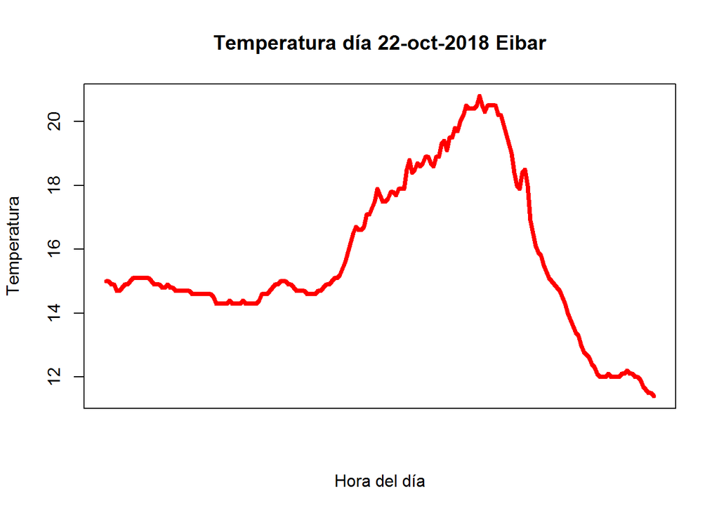

```r
plot(rev(Datos_dia_22_oct$`temp (ÂºC)`),
     xlab = "Hora del día",
     ylab = "Temperatura",
     main= "Temperatura día 22-oct-2018 Eibar",
     xaxt="n",
     type = "l",
     lwd = 4,
     col= "red")
```

Se puede añadir una “grid” a la gráfica facilmente. Esta grid se puede modificar, indicando el número de celdas o incluso, cambiando el estilo de la misma. Si ejecutamos únicamente grid(), se añade una por defecto.

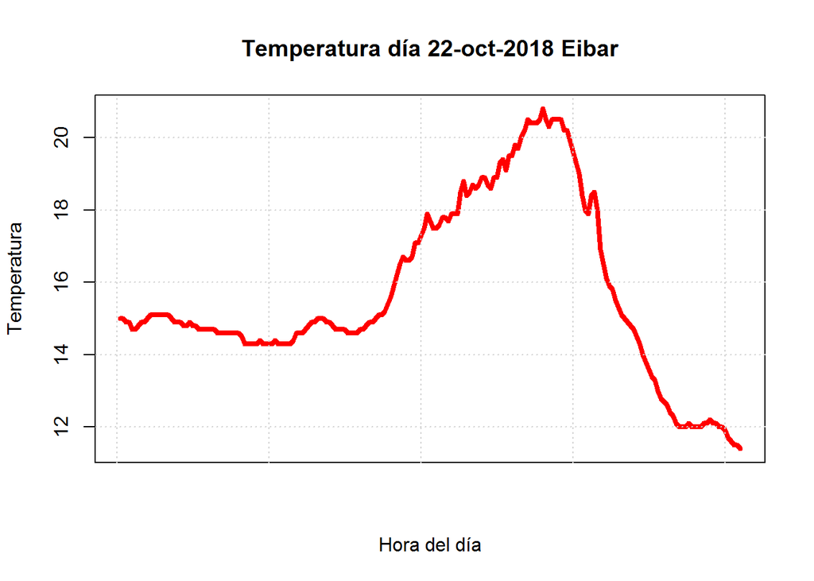

```r
grid()
```

# Añadir puntos a una gráfica.

Muchas veces es necesario remarcar un punto concreto dentro de una gráfica. Para ello emplemos *points()*. Points directamente añade un punto a una gráfica existente. Por ejemplo añadamos al ejemplo anterior el punto de máxima temperatura.

Para usar points hay que marcar posición x e y.

- x: posición del máximo (OJO: vector invertido)
- y: valor del máximo

```r
y <- max(Datos_dia_22_oct$`temp (ÂºC)`)
x <- which.max(rev(Datos_dia_22_oct$`temp (ÂºC)`))
```

Quizas los parámetros más utilizados en points sean:

- pch: tipo de punto. Se indica un número que se relaciona con un tipo de punto.

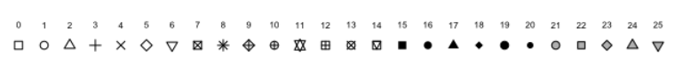

- cex: tamaño del punto. cex=1 por defecto.

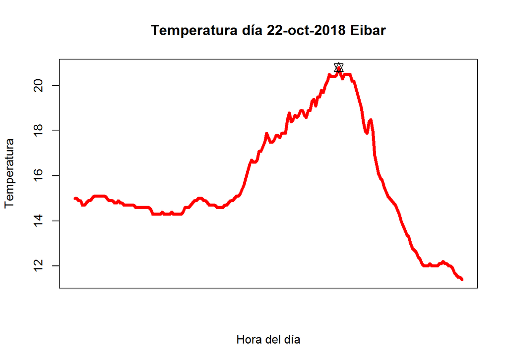

```r
plot(rev(Datos_dia_22_oct$`temp (ÂºC)`),
     xlab = "Hora del día",
     ylab = "Temperatura",
     main= "Temperatura día 22-oct-2018 Eibar",
     xaxt="n",
     type = "l",
     lwd = 4,
     col= "red")


#Añado puntos a la anterior gráfica
points(x,y, pch=11, cex=1.25)
```

# Añadir texto a una gráfica.

Existe un comando llamado text(), que añade texto a una gráfica. Hay que indicar la posición del texto y lo que se quiere que aparezca en el texto.

## Comando paste y paste0.

Es muy recurrente tener que construir texto a partir de valores y valores mezclados con texto. Para ello se emplea paste o paste0. La única diferencia entre ellos es que paste pega los elementos que queremos con espacio (incluso podemos modificar el caracter entre elementos) y parse0 los pega sin espacio entre ellos

```r
paste(max(Datos_dia_22_oct$`temp (ÂºC)`), "ºC")
```

```
## [1] "20.8 ºC"
```

```r
paste(max(Datos_dia_22_oct$`temp (ÂºC)`), "ºC", sep = "_")
```

```
## [1] "20.8_ºC"
```

```r
paste0(max(Datos_dia_22_oct$`temp (ÂºC)`), "ºC")
```

```
## [1] "20.8ºC"
```

## Comando text()

Una vez sabemos las coordenadas para añadir el texto (mismas coordenadas que el punto) y el texto que queremos añadir usamos el comando text() para añadirlo a la gráfica.

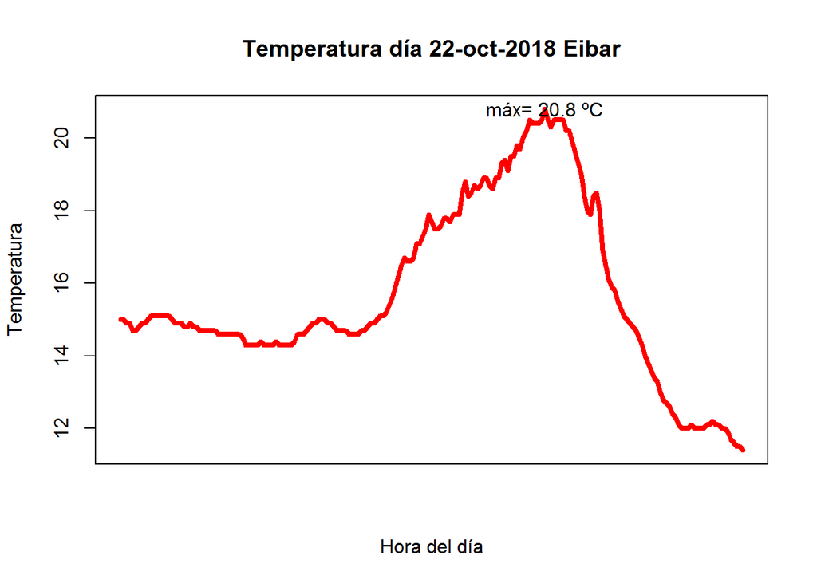

```r
plot(rev(Datos_dia_22_oct$`temp (ÂºC)`),
     xlab = "Hora del día",
     ylab = "Temperatura",
     main= "Temperatura día 22-oct-2018 Eibar",
     xaxt="n",
     type = "l",
     lwd = 4,
     col= "red")


text_max <- paste("máx=",max(Datos_dia_22_oct$`temp (ÂºC)`), "ºC")

text(x,y, labels = text_max)
```

Si vemos que se suporponen con la gráfica podemos modificar a mano la posición x o y para ajustarlo.

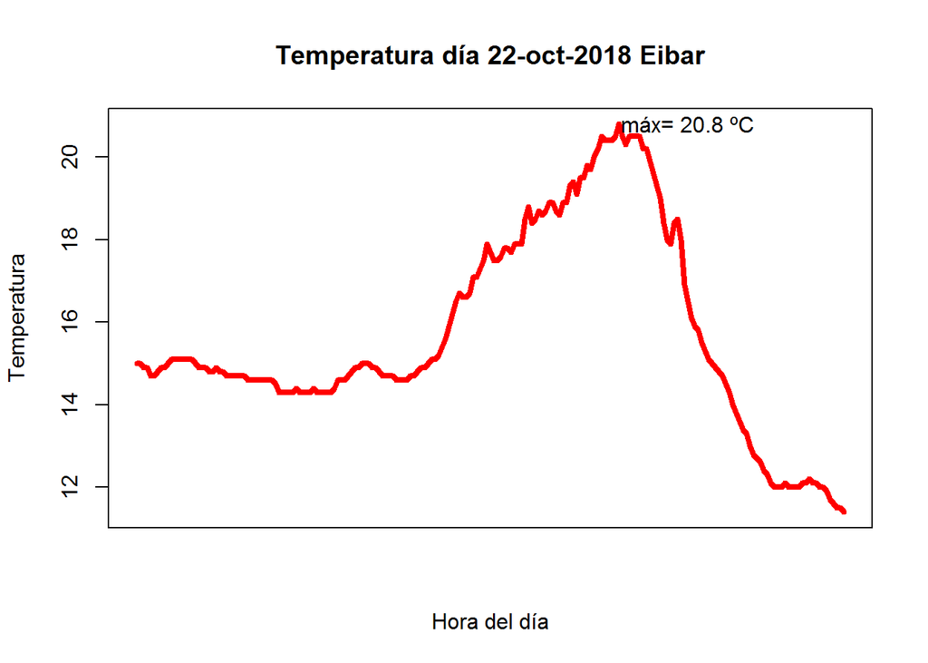

```r
plot(rev(Datos_dia_22_oct$`temp (ÂºC)`),
     xlab = "Hora del día",
     ylab = "Temperatura",
     main= "Temperatura día 22-oct-2018 Eibar",
     xaxt="n",
     type = "l",
     lwd = 4,
     col= "red")


text(x+20,y, labels = text_max)
```

# Paquete lubridate.

Este paquete está destinado a trabajar con fechas. De esta manera facilita el poder navegar dentro de una serie temporal, buscando días concretos, intervalos temporales, etc.

```r
library(lubridate)
```

```r
class(Datos_dia_22_oct$date_string_hour[1])
```

```
## [1] "factor"
```

## Conversión a formato fecha

Nos fijamos que la columna que refleja las fechas en formato palabra, es tipo “factor”. Para poder explotar al máximo la versatilidad del paquete “lubridate”. Para ello realizamos una doble transformación: de “factor” a “character” (palabra) y de “character” a “date” (formato fecha).

```r
Datos_dia_22_oct[,2] <-dmy_hms(
  as.character(
    Datos_dia_22_oct$date_string_hour))

#Comprobamos la clase de de la columna
class(Datos_dia_22_oct$date_string_hour)
```

```
## [1] "POSIXct" "POSIXt"
```

**Tanto el formato POSIXct como el POSIxt son formatos de fecha** y el lubridate los identifica como tal.  
Esto nos ofrece varias posibilidades para manipular y seleccionar datos por intervalos temporales. Hay que tener en cuenta que su formato sea tipo “fecha” guarda información oculta como el sistema de medida y la fecha en segundos desde el 1 de enero de 1970.

```r
unclass(Datos_dia_22_oct$date_string_hour[1])
```

```
## [1] 1540252601
## attr(,"tzone")
## [1] "UTC"
```

## Posibilidades del paquete lubridate

Este paquete tambien es capaz de identificar segundos, minutoos, horas, días, meses. Partiendo de la primera fecha de la tabla.

```r
Datos_dia_22_oct$date_string_hour[1]
```

```
## [1] "2018-10-22 23:56:41 UTC"
```

```r
second(Datos_dia_22_oct$date_string_hour[1])
```

```
## [1] 41
```

```r
minute(Datos_dia_22_oct$date_string_hour[1])
```

```
## [1] 56
```

```r
hour(Datos_dia_22_oct$date_string_hour[1])
```

```
## [1] 23
```

```r
day(Datos_dia_22_oct$date_string_hour[1])
```

```
## [1] 22
```

```r
month(Datos_dia_22_oct$date_string_hour[1])
```

```
## [1] 10
```

```r
year(Datos_dia_22_oct$date_string_hour[1])
```

```
## [1] 2018
```

Esto nos permitirá poder seleccionar de manera sencilla agrupar los datos por estaciones, meses, semanas, etc.

## Ejemplo

A modo de ejemplo vamos a comparar las temperaturas y humedades del *dataset* term_hig7. Primero transformamos la columna *date_string_hour* en formato fecha como ya vimos anteriormente.

```r
term_hig7$date_string_hour <- dmy_hms(
  as.character(
    term_hig7$date_string_hour))
```

### Comando unique()

Si ejecutamos week, con toda la columna en formato fecha nos dirá a que semana del año pertenece cada dato, es decir: un vector de 6000 elementos. Si a nosotros lo que nos interesa ver es cuantos elementos diferentes hay podemos ejecutar *unique()* que únicamente sacará por consola elementos que sean diferentes.

```r
week(term_hig7$date_string_hour)
```

```
##    [1] 43 43 43 43 43 43 43 43 43 43 43 43 43 43 43 43 43 43 43 43 43 43 43
##   [24] 43 43 43 43 43 43 43 43 43 43 43 43 43 43 43 43 43 43 43 43 43 43 43
##   [47] 43 43 43 43 43 43 43 43 43 43 43 43 43 43 43 43 43 43 43 43 43 43 43
##   [70] 43 43 43 43 43 43 43 43 43 43 43 43 43 43 43 43 43 43 43 43 43 43 43
##   [93] 43 43 43 43 43 43 43 43 43 43 43 43 43 43 43 43 43 43 43 43 43 43 43
##  [116] 43 43 43 43 43 43 43 43 43 43 43 43 43 43 43 43 43 43 43 43 43 43 43
##  [139] 43 43 43 43 43 43 43 43 43 43 43 43 43 43 43 43 43 43 43 43 43 43 43
##  [162] 43 43 43 43 43 43 43 43 43 43 43 43 43 43 43 43 43 43 43 43 43 43 43
##  [185] 43 43 43 43 43 43 43 43 43 43 43 43 43 43 43 43 43 43 43 43 43 43 43
##  [208] 43 43 43 43 43 43 43 43 43 43 43 43 43 43 43 43 43 43 43 43 43 43 43
##  [231] 43 43 43 43 43 43 43 43 43 43 43 43 43 43 43 43 43 43 43 43 43 43 43
##  [254] 43 43 43 43 43 43 43 43 43 43 43 43 43 43 43 43 43 43 43 43 43 43 43
##  [277] 43 43 43 43 43 43 43 43 43 43 43 43 43 43 43 43 43 43 43 43 43 43 43
##  [300] 43 43 43 43 43 43 43 43 43 43 43 43 43 43 43 43 43 43 43 43 43 43 43
##  [323] 43 43 43 43 43 43 43 43 43 43 43 43 43 43 43 43 43 43 43 43 43 43 43
```

[output cut: 258 more lines]

```r
unique(week(term_hig7$date_string_hour))
```

```
## [1] 43 42 41 40 39 38
```

### Comando table()

Otro comando muy recurrente es el comando table. Que es capaz de contar los elementos iguales de un vector.

```r
table(week(term_hig7$date_string_hour))
```

```
##
##   38   39   40   41   42   43
##  188 1434 1434 1434 1432  345
```

Nos damos que cuenta que tanto la semana 38 y lal 43 son semanas incompletas encuanto a datos se refiere. Usaremos los datos de las semanas 39,40,41 y 42.

# Iniciación a los bucles

Para separar estos datos y tratarlos de manera individualizada se puede hacer de varias maneras diferentes, seguro que de manera más sencilla, pero voy a realizar esta labor empleando **bucles for**. *NEXT LEVEL¡*.  
Un bucle es algo que se ejecuta de manera cíclica, en la que cada vez que se ejecutan se pueden variar los valores y ahorrar tiempo. Es decir, si tengo que obtener 25 gráficas lo puedo hacer con un bucle de 25 cíclos y no tengo que ejecutar 25 veces el mismo código. *EFICIENCIA*.  
es interesante saber cual es la mecánica de un bucle. A mi me gusta seguir más o menos estas guías:

- Creo una lista, matriz o vector que posteriormente se va a rellenar
- Creo vectores de valores que van a ser utilizados en el bucle
- Hago el bucle, que básicamente coje valores de los vectores realiza una acción y guarda la información en una lista, matriz o vector vacía.

```r
#Creo lista vacía para rellenar
Datos_semanas <- list()

#Vector de valores a utilizar, Dijimos que vamos a utilizar semana 39,40,41 y 42
semana <- 39:42

for (i in 1:4) {

x <- term_hig7[week(term_hig7$date_string_hour) == semana[i], ]
Datos_semanas[[i]] <- x
}
```

para aclararnos podemos nombrar los elementos de la lista usando el vector “semanas”.

```r
names(Datos_semanas)<- semana
```

Los bucles se pueden ejecutar de maneras diferentes. **Imaginación y orden es lo único que hace falta para lograr optimizar nuestro trabajo y nuestro código**, minimizando el tiempo de programación empleando bucles que ejecuten muchas acciones de manera rápida.  
Este cometido se puede lograr empleando varias lógicas diferentes. Por ejemplo:

```r
Datos_semanas_2 <- list()
for (i in 39:42) {

Datos_semanas_2[[i-38]] <- term_hig7[week(term_hig7$date_string_hour) == i,]
}
```

Este ejercicio es unicamente para introduciros en los bucles. esto se puede complejizar usando bucles *if y while* que veremos en capítulos más adelante. **Es importante controlar los bucles muy bien, por ello, os animo a pensar siempre en una programación enfocada a la eficiencia del código, basada en bucles**. Si puedo lograr que mi código tenga 50 líneas, empleando muchos bucles cortos en vez de 150 líneas a pelo, mucho mejor.

# Gráficos combinados.

Para hacer una demuestración de como combinar gráficos primero lo que vamos a hacer es realizar una media diaria.

```r
Agrupacion_semanas <- data.frame()
medias_diarias <- vector()
for (i in 1:4) {

  for (j in 1:7) {
     x <- Datos_semanas[[i]][wday(Datos_semanas[[i]]$date_string_hour,
                               week_start = 1) == j,]
     medias_diarias[j] <- mean(x$`temp (ÂºC)`)

  }
 Agrupacion_semanas <- rbind(Agrupacion_semanas,medias_diarias)

}

colnames(Agrupacion_semanas) <- c("L", "M","X","J", "V", "S", "D")
row.names(Agrupacion_semanas)<- 39:42
```

Podemos ver que aspecto tiene el resultado de este bucle. Nótese que la labor de nombrar columnas filas, listas etc. se suele ejecutar fuera del bucle.

```r
View(Agrupacion_semanas)
```

## El uso de lines()

Una manera de realizar gráficos combinados es usar el comando lines(). Lo que hace es, siempre una vez se ha ejecutado un plot() primeramente, realiza un plot añadiendose al plot principal.

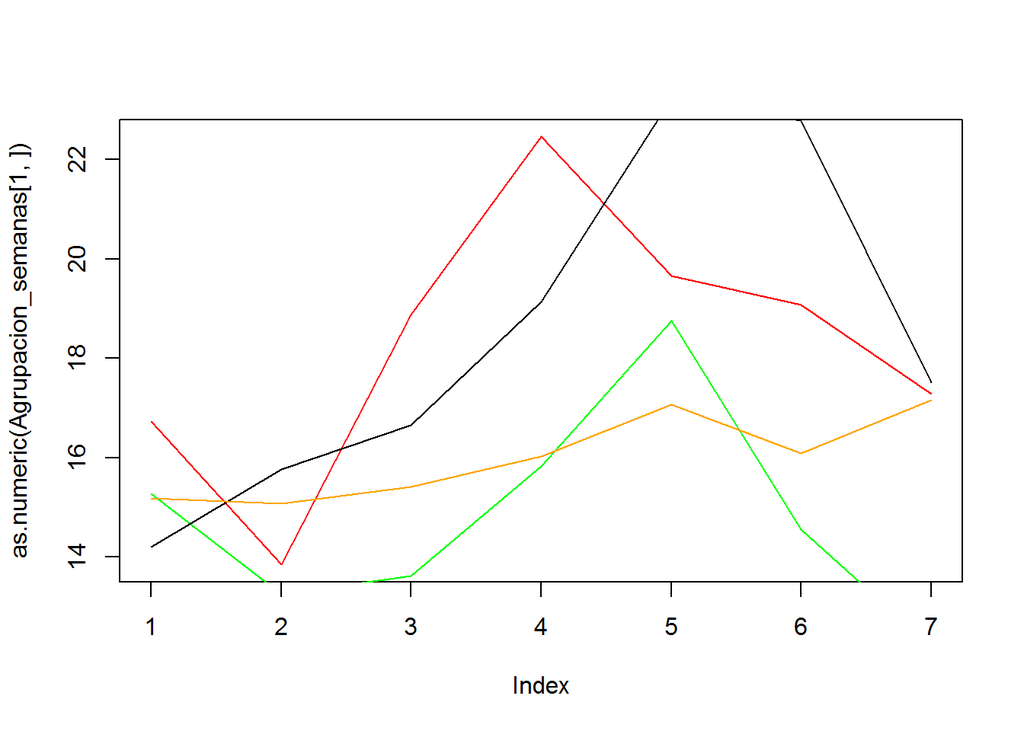

```r
plot(as.numeric(Agrupacion_semanas[1,]),type = "l",col="red")
lines(as.numeric(Agrupacion_semanas[2,]), col="green")
lines(as.numeric(Agrupacion_semanas[3,]),col="black")
lines(as.numeric(Agrupacion_semanas[4,]),col="orange")
```

Si hay datos fuera del gráfico, se puede modificar el ylim (rango de y) para forzar a la gráfica a contener todos los datos, esto se tiene que incluir en el primer plot.

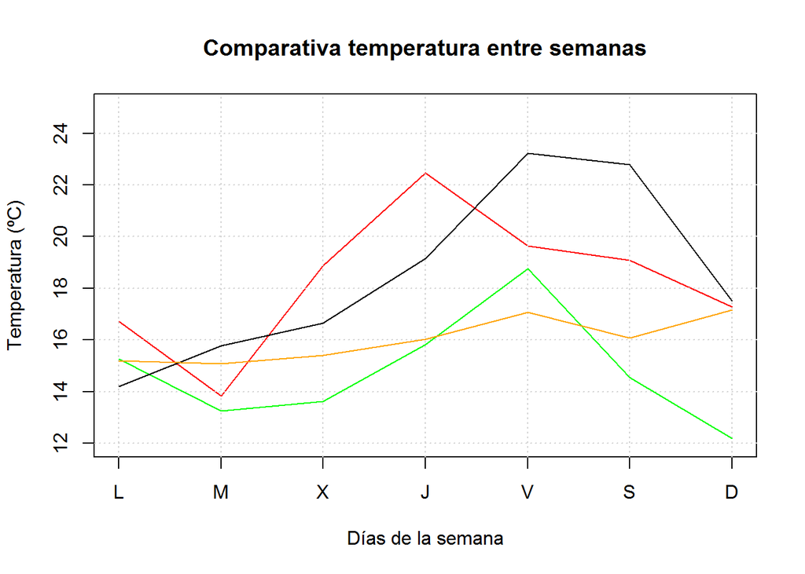

```r
plot(as.numeric(Agrupacion_semanas[1,]),
     type = "l",
     col="red",
     ylim = c(12,25),
     xlab = "Días de la semana",
     ylab = "Temperatura (ºC)",
     xaxt="n",
     main = "Comparativa temperatura entre semanas")

axis(1,at = 1:7,labels = colnames(Agrupacion_semanas))
grid()

lines(as.numeric(Agrupacion_semanas[2,]), col="green")
lines(as.numeric(Agrupacion_semanas[3,]),col="black")
lines(as.numeric(Agrupacion_semanas[4,]),col="orange")
```

## Añadir leyenda a una gráfica. Comando legend()

El hecho de tener varias informaciones superpuestas en una única gráfica obliga a tener que añadir una leyenda que nos permita diferenciar cada variable.

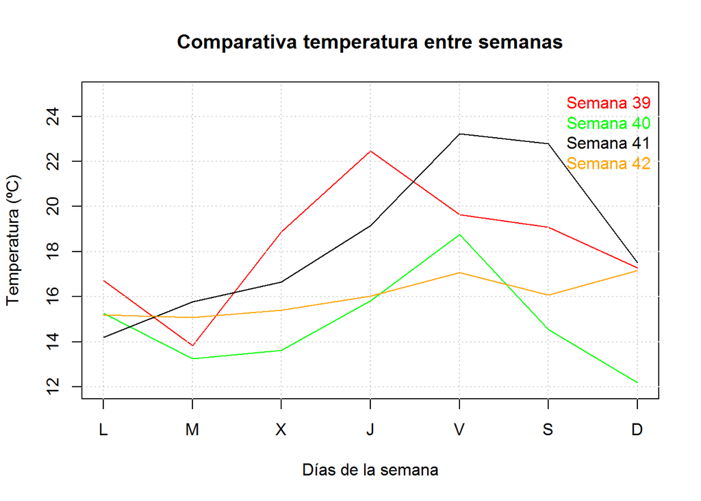

```r
legend("topright", legend = c("Semana 39",
                          "Semana 40",
                          "Semana 41",
                          "Semana 42"),
       text.col = c("red","green","black","orange"),
       cex = 1,
       bty = "n")
```

Se puede hacer mucho mejor, legend() ofrece cambiar muchos parámetros de estilo.  
Otro ejercicio interesante es plotear las medias semanales, Para ver más claramente cual fue la semana más fría. Aunque se puede intuir que es la semana 40.  
Primero obtenemos las medias semanales.

```r
medias_semanales<- vector()
for (i in 1:4) {
  x<- mean(as.numeric(Agrupacion_semanas[i,]))
  medias_semanales[i] <- x

}
```

Hay que tener en cuenta el orden el vector medias semanales está organizado desde la semana 39 (elemento 1) hasta la semana 42 (elemento 4)

Para plotear la línea de temperatura media, tendremos que generar un vector cuyo valor se repita una serie de veces. Para ello usaremos *rep()*, que crear un vector que repite el valor de x, tantas veces le indiquemos.Esto nos puede ayudar a plotear líneas rectas en los gráficos. Como pueden ser valores medios.

## Comando par(new=TRUE)

En este apartado también veremos como se pueden hacer gráficos conjuntos, por otro método. usaremoso **par(new=TRUE)**. Que básicamente lo que dice es: añade el siguiente gráfico al gráfico existente.

—

**Nótese que para que esta manera de hilar gráficos funcione, se tienen que haber ejecutado una gráfica a la que se añada esta nueva.**

Añadimos las sucesivas líneas usando un bucle.

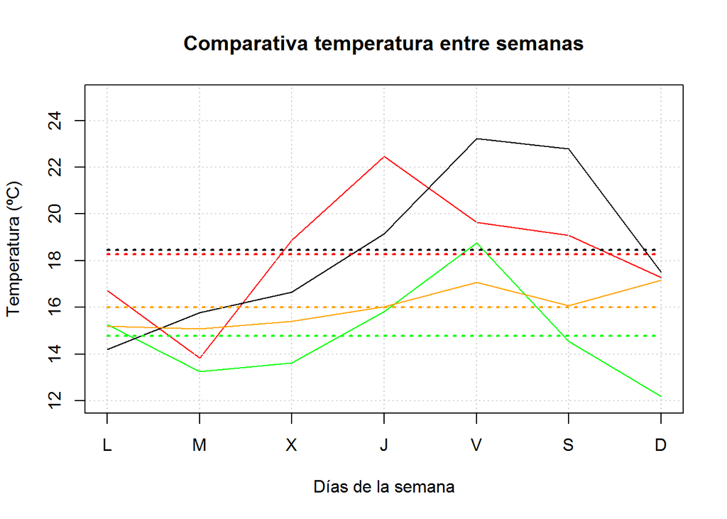

```r
plot(as.numeric(Agrupacion_semanas[1,]),
     type = "l",
     col="red",
     ylim = c(12,25),
     xlab = "Días de la semana",
     ylab = "Temperatura (ºC)",
     xaxt="n",
     main = "Comparativa temperatura entre semanas")

axis(1,at = 1:7,labels = colnames(Agrupacion_semanas))
grid()

lines(as.numeric(Agrupacion_semanas[2,]), col="green")
lines(as.numeric(Agrupacion_semanas[3,]),col="black")
lines(as.numeric(Agrupacion_semanas[4,]),col="orange")

#Ahora ploteamos encima las medias
colores <-  c("red","green","black","orange")

for (j in 1:4) {

  vector_media <- rep(medias_semanales[j],7)

  par(new=TRUE)

  plot(vector_media,
       type = "l",
       ylim = c(12,25),
       col= colores[j],
       lty=3,
       lwd=2,
       xaxt="n",
       yaxt="n",
       ylab = "",
       xlab = "")

}
```

Lo anteriormente visto nos sirve para darnos cuenta del potencial que tienen los bucles, tanto para extraer información como para manejarla y graficar dicha información.

## Plotear líneas rectas, comando abline()

Pero, para proximas veces que queramos representar una media, como una línea recta. Existe una comando especialmente pensado para ello. Este comando es **abline()**. Este comando se usa, para representar líneas en las gráficas, tanto verticales como diagonales u horizontales. En nuestro caso nos interesa que las líneas sean horizontales.  
Antes de nada representamos de nuevo el gráfico principal.

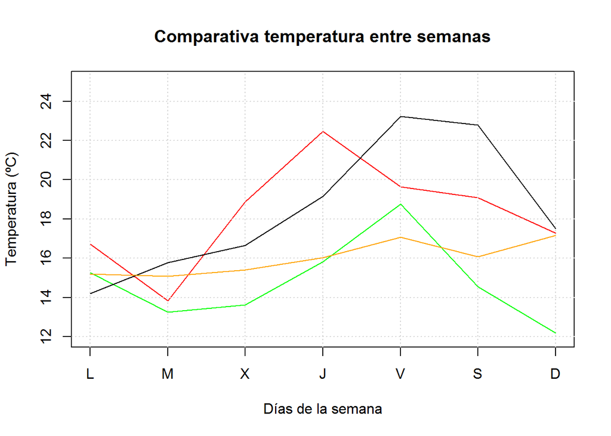

```r
plot(as.numeric(Agrupacion_semanas[1,]),
     type = "l",
     col="red",
     ylim = c(12,25),
     xlab = "Días de la semana",
     ylab = "Temperatura (ºC)",
     xaxt="n",
     main = "Comparativa temperatura entre semanas")

axis(1,at = 1:7,labels = colnames(Agrupacion_semanas))
grid()

lines(as.numeric(Agrupacion_semanas[2,]), col="green")
lines(as.numeric(Agrupacion_semanas[3,]),col="black")
lines(as.numeric(Agrupacion_semanas[4,]),col="orange")
```

Sobre el gráfico principal representamos las líneas horizontales usando abline.

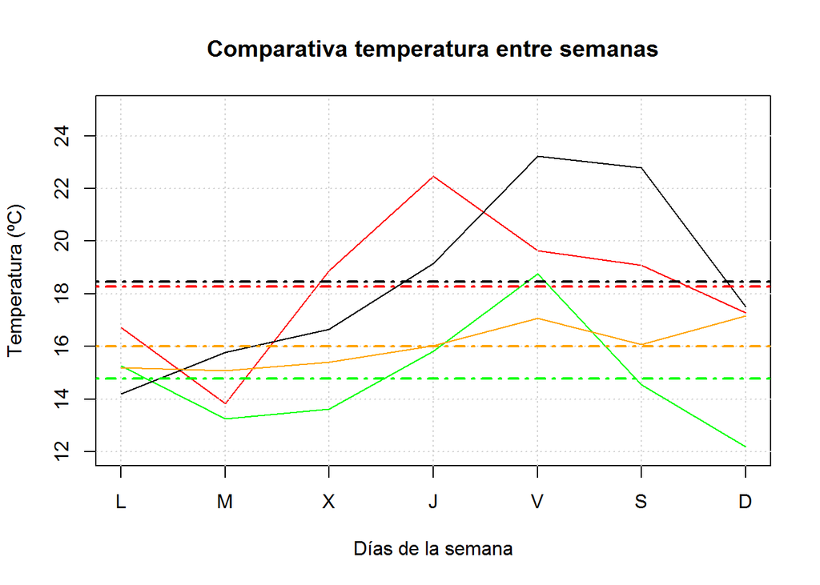

```r
colores <-  c("red","green","black","orange")

#usamos h =... porque queremos lineas horizontales
abline(h=medias_semanales, col=colores, lty=4, lwd=2)
```

# Moralina

Las posibilidades que ofrece Rstudio a la hora de representar datos es inmensa. Existen comandos especifícos para hacer histogramas, boxplots, diagramas de barras, diagramas polares y un largo etc. Que en este capítulo no hemos abordado.  
Esta guía simplemente quiere haceros entender que existen muchas maneras diferentes (unas más eficientes que tras) para lograr el mismo cometido y hay es donde a la hora de programar podemos dar nuestro toque personal.

En este capítulo he decidido meter una pequeña introducción a los bucles for. Es normal que de primeras choque y también es muy normal que no entendamos el funcionamiento de los mismos. **TRANQUILIDAD**, tenemos mucho tiempo para llegar a dominar los bucles y es algo que se aprende haciendo, obteniendo fallos y warnings de todo tipo hasta que al final sale. **NO DESESPERÉIS, YA HARÉ ALGUNA GUÍA ENFOCADA ÚNICAMENTE A BUCLES**.

Tambien se ha realizado una introducción al **paquete lubridate**. Es muy versatil y mejor verlo cuanto antes. *Saber que un paquete existe no es lo mismo que dominarlo* y yo únicamente pretendo que sepáis que existe. Es decir, la proxima vez que quieran trabajar con fechas, no van a saber utilizar el paquete lubridate, pero sabrán que existe y buscar información al respecto es muy sencillo.

Si es verdad que los gráficos en R, pueden realizarse mediante diferentes paquetes que nos ofrecen nuevas posibilidades. Es muy interesante el paquete **ggplot2**. Este paquete está enfocado a realizar gráficas, pero tambien enfocado a trabajar con un paradigma diferente de organización de los datos. Véase el paquete **dplyr**, un paquete muy muy potente. En el que profundizaremos un poco más adelante. Cabe mencionar, que al principio, cuando descubrimos una herramienta nueva, lo mas normal es que nos lleve mucho tiempo dominarla (por ejemplo la pareja *ggplot2+dplyr*), pero a la larga conseguirá que ahorremos tiempo y esfuerzo, lo prometo. Con esto no pretendo que empecéis a empoyar paquetes de R, pero es bueno tener claro que la programación y el tratamiento de datos no es un camino fijo, existen mil maneras de llegar al objetivo, y depende de nosotros elegir esa manera.